# Ford GoBike System Data Analysis

## Introduction

> This data set includes information about individual rides made in a bike-sharing system covering the greater San Francisco Bay area.

## Preliminary Wrangling

> This document explores a dataset containing about 183,000 bike records and 16 features that clearly show details of how bikes are shared amongst riders.

```python
# import all packages and set plots to be embedded inline
import numpy as np
import pandas as pd
import matplotlib.pyplot as plt
import seaborn as sb

%matplotlib inline
```

```python
# load in the dataset into a pandas dataframe
df = pd.read_csv('201902-fordgobike-tripdata.csv')
```

```python
# print the shape and data type of the loaded data
print(df.shape)
print(df.dtypes)
print(df.head(5))
```

```
(183412, 16)
duration_sec                 int64
start_time                  object
end_time                    object
start_station_id           float64
start_station_name          object
start_station_latitude     float64
start_station_longitude    float64
end_station_id             float64
end_station_name            object
end_station_latitude       float64
end_station_longitude      float64
bike_id                      int64
user_type                   object
member_birth_year          float64
member_gender               object
bike_share_for_all_trip     object
dtype: object
   duration_sec                start_time                  end_time  \
0         52185  2019-02-28 17:32:10.1450  2019-03-01 08:01:55.9750
1         42521  2019-02-28 18:53:21.7890  2019-03-01 06:42:03.0560
2         61854  2019-02-28 12:13:13.2180  2019-03-01 05:24:08.1460
3         36490  2019-02-28 17:54:26.0100  2019-03-01 04:02:36.8420
4          1585  2019-02-28 23:54:18.5490  2019-03-01 00:20:44.0740

   start_station_id                                start_station_name  \
0              21.0  Montgomery St BART Station (Market St at 2nd St)
1              23.0                     The Embarcadero at Steuart St
2              86.0                           Market St at Dolores St
3             375.0                           Grove St at Masonic Ave
4               7.0                               Frank H Ogawa Plaza

   start_station_latitude  start_station_longitude  end_station_id  \
0               37.789625              -122.400811            13.0
1               37.791464              -122.391034            81.0
2               37.769305              -122.426826             3.0
3               37.774836              -122.446546            70.0
4               37.804562              -122.271738           222.0

                               end_station_name  end_station_latitude  \
0                Commercial St at Montgomery St             37.794231
1                            Berry St at 4th St             37.775880
2  Powell St BART Station (Market St at 4th St)             37.786375
3                        Central Ave at Fell St             37.773311
4                         10th Ave at E 15th St             37.792714

   end_station_longitude  bike_id   user_type  member_birth_year  \
0            -122.402923     4902    Customer             1984.0
1            -122.393170     2535    Customer                NaN
2            -122.404904     5905    Customer             1972.0
3            -122.444293     6638  Subscriber             1989.0
4            -122.248780     4898  Subscriber             1974.0

  member_gender bike_share_for_all_trip
0          Male                      No
1           NaN                      No
2          Male                      No
3         Other                      No
4          Male                     Yes
```

```python
# Determine if there is a NA value and the sum of it in each column
df.isna().sum()
```

```
duration_sec                  0
start_time                    0
end_time                      0
start_station_id            197
start_station_name          197
start_station_latitude        0
start_station_longitude       0
end_station_id              197
end_station_name            197
end_station_latitude          0
end_station_longitude         0
bike_id                       0
user_type                     0
member_birth_year          8265
member_gender              8265
bike_share_for_all_trip       0
dtype: int64
```

```python
# The pandas to_datetime function will be used to convert the columns with wrong data types to its supposed data type
df['start_time'] = pd.to_datetime(df['start_time'])
df['end_time'] = pd.to_datetime(df['end_time'])
```

> The above line of code is for conversion of object data type to datetime.

```python
# reprint the data types to make sure that the above changes took effect
print(df.dtypes)
```

```
duration_sec                        int64
start_time                 datetime64[ns]
end_time                   datetime64[ns]
start_station_id                  float64
start_station_name                 object
start_station_latitude            float64
start_station_longitude           float64
end_station_id                    float64
end_station_name                   object
end_station_latitude              float64
end_station_longitude             float64
bike_id                             int64
user_type                          object
member_birth_year                 float64
member_gender                      object
bike_share_for_all_trip            object
dtype: object
```

> The above output shows that the columns *(start_time and end_time) with incorrect data types were changed.

```python
print(df.describe())
```

```
        duration_sec  start_station_id  start_station_latitude  \
count  183412.000000     183215.000000           183412.000000
mean      726.078435        138.590427               37.771223
std      1794.389780        111.778864                0.099581
min        61.000000          3.000000               37.317298
25%       325.000000         47.000000               37.770083
50%       514.000000        104.000000               37.780760
75%       796.000000        239.000000               37.797280
max     85444.000000        398.000000               37.880222

       start_station_longitude  end_station_id  end_station_latitude  \
count            183412.000000   183215.000000         183412.000000
mean               -122.352664      136.249123             37.771427
std                   0.117097      111.515131              0.099490
min                -122.453704        3.000000             37.317298
25%                -122.412408       44.000000             37.770407
50%                -122.398285      100.000000             37.781010
75%                -122.286533      235.000000             37.797320
max                -121.874119      398.000000             37.880222

       end_station_longitude        bike_id  member_birth_year
count          183412.000000  183412.000000      175147.000000
mean             -122.352250    4472.906375        1984.806437
std                 0.116673    1664.383394          10.116689
min              -122.453704      11.000000        1878.000000
25%              -122.411726    3777.000000        1980.000000
50%              -122.398279    4958.000000        1987.000000
75%              -122.288045    5502.000000        1992.000000
max              -121.874119    6645.000000        2001.000000
```

### What is the structure of your dataset?

> There were 183412 number of rows and 16 number of columns in the dataset. There are two (2) columns with datetime data type, two (2) columns that are of integer data type, seven (7) cloumns with a float data type and five (5) cloumns with an object data type. It is certain that more columns will be created in my bid to effectively clean the data.

### What is/are the main feature(s) of interest in your dataset?

> I am interested in finding out what features in the dataset are best for predicting that a rider will have to share his/her bike.

### What features in the dataset do you think will help support your investigation into your feature(s) of interest?

> My hypothesis is that riders that are old based on their birth_year may likely share a bike, user_type might also influence a riders decision to share a bike if they are on subscription, they might want to let other people use their bike when they are not making use of it. I also think that gender type will also prompt bike sharing but to a smaller degree as compared to member_birth_year. Duration might also cause one to share a bike which also might be affected by the start station and end station.

## Univariate Exploration

> First of, lets see the Distribution of time taken for rides (duration_sec)

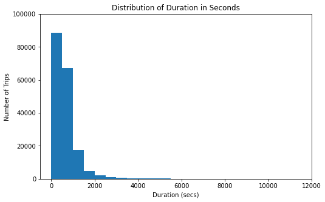

```python
# A histogram plot of duration_sec to get the frequency distribution
binsize = 500
bins = np.arange(0, df['duration_sec'].max()+binsize, binsize)

plt.figure(figsize=[8, 5])
plt.hist(data = df, x = 'duration_sec', bins = bins)
plt.title('Distribution of Duration in Seconds')
plt.xlabel('Duration (secs)')
plt.ylabel('Number of Trips')
plt.axis([-500, 12000, 0, 100000])
plt.show()
```

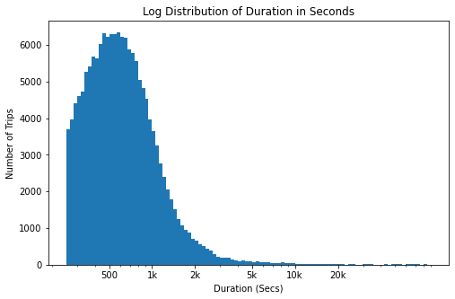

```python
# Distribution is skewd to the right. So let's put it on a log scale instead to get a proper view
log_binsize = 0.025
bins = 10 ** np.arange(2.4, np.log10(df['duration_sec'].max())+log_binsize, log_binsize)

plt.figure(figsize=[8, 5])
plt.hist(data = df, x = 'duration_sec', bins = bins)
plt.xscale('log')
plt.xticks([500, 1e3, 2e3, 5e3, 1e4, 2e4], [500, '1k', '2k', '5k', '10k', '20k'])
plt.title('Log Distribution of Duration in Seconds')
plt.xlabel('Duration (Secs)')
plt.ylabel('Number of Trips')
plt.show()
```

> The birth year of members were given but the age wasn't. Up next, we will check the distribution of the member_birth_year.

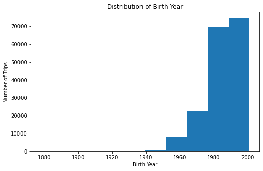

```python
# plot a histogram of member_birth_year its distribution on number of trips

plt.figure(figsize=[8, 5])
plt.hist(data = df.dropna(), x = 'member_birth_year')
plt.title('Distribution of Birth Year')
plt.xlabel('Birth Year')
plt.ylabel('Number of Trips')
plt.show()
```

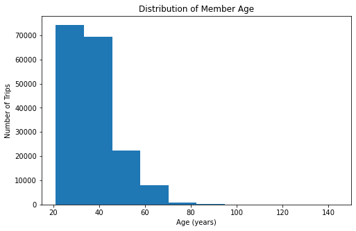

```python
# Age column was created, a histogram will be plotted to see distribution.
df['age'] = 2022 - df['member_birth_year']


binsize = 2
bins = np.arange(0, df['age'].max()+binsize, binsize)

plt.figure(figsize=[8, 5])
plt.hist(data = df.dropna(), x = 'age')
plt.title('Distribution of Member Age')
plt.xlabel('Age (years)')
plt.ylabel('Number of Trips')
plt.show()
```

> If you recall, our member_birth_year distribution was skewed to the left (meaning persons from year 1980 down to recent years (2000) had more rides. The above plotted age distribution has confirmed that members below 50 had more rides and also, that riders between age 20 - 40 had the highest rides.

> Up next, I will feature engineer the start_time and end_time to get the start_day and end_day. A countplot with seaborn will be used to see the days with highest number of trips.

```python
# code that creates our supposed columns and also, get the day from each respective datetime column
df['start_day'] = df['start_time'].dt.day_name()
df['end_day'] = df['end_time'].dt.day_name()
```

> Up next, we will plot a countplot of start_day and end_day to see days with highest number of trips.

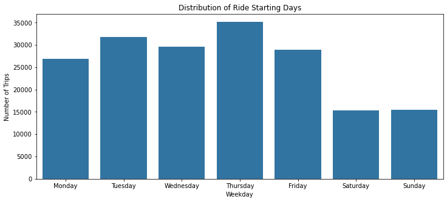

```python
# plot start_day to see ride starting days with highest count of trips
base_color = sb.color_palette()[0]

plt.figure(figsize=[12, 5])
sb.countplot(x='start_day', data=df, color=base_color, order = ['Monday', 'Tuesday', 'Wednesday', 'Thursday', 'Friday',
                                                                'Saturday', 'Sunday'])
plt.title('Distribution of Ride Starting Days')
plt.xlabel('Weekday')
plt.ylabel('Number of Trips')
plt.show()
```

> Plot the end day to equally get days with their respective trip counts.

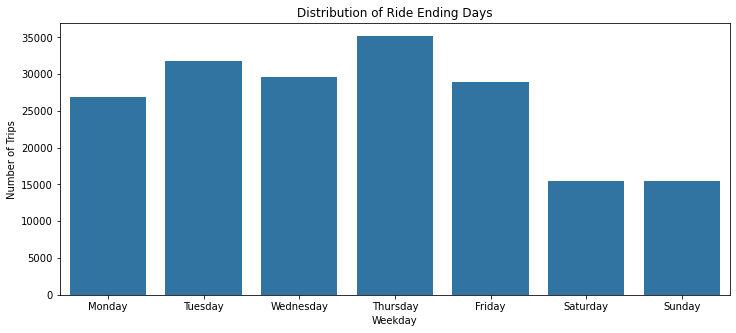

```python
# plot end_day to see ride ending days with highest count of trips
base_color = sb.color_palette()[0]


plt.figure(figsize=[12, 5])
sb.countplot(x='end_day', data=df, color=base_color, order = ['Monday', 'Tuesday', 'Wednesday', 'Thursday', 'Friday',
                                                                'Saturday', 'Sunday'])
plt.title('Distribution of Ride Ending Days')
plt.xlabel('Weekday')
plt.ylabel('Number of Trips')
plt.show()
```

> The graph for ride start days and end days follow the same pattern. If you look closely, you will see that the day with most rides is also the day most rides ended.

> plot the chosen category features from the list of features present in the dataset

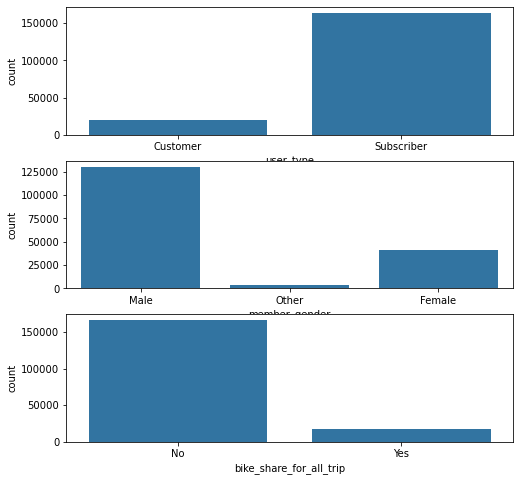

```python
# plot a countplot to see distribution of categorical vairable
fig, ax = plt.subplots(nrows=3, figsize = [8,8])

default_color = sb.color_palette()[0]
sb.countplot(data = df, x = 'user_type', color = default_color, ax = ax[0])
sb.countplot(data = df, x = 'member_gender', color = default_color, ax = ax[1])
sb.countplot(data = df, x = 'bike_share_for_all_trip', color = default_color, ax = ax[2])



plt.show()
```

### Of the features you investigated, were there any unusual distributions? Did you perform any operations on the data to tidy, adjust, or change the form of the data? If so, why did you do this?

> At first, I changed the data type of the start_time and end_time from object to datetime. The conversion was to get the appropraite data type which will be of a great help if I decide to do a feature engineering so as to get the days of trip, start day and end day. The start day and end day was created. I also had to perform a feature engineering on the year column to get age for further analysis. I had to substract the year column from the current year. As earlier stated, unusual findings were seen on the year, age, bike sharing trip and start day for rides and end day having same pattern.

## Bivariate Exploration

> Up next, lets see the plot representation of correlation between numeric columns of our dataset.

```python
numeric_vars = ['duration_sec', 'start_station_id', 'start_station_latitude', 'start_station_longitude',
                'end_station_id', 'end_station_latitude', 'end_station_longitude', 'bike_id', 'member_birth_year', 'age']

categoric_vars = ['user_type', 'member_gender', 'bike_share_for_all_trip']
```

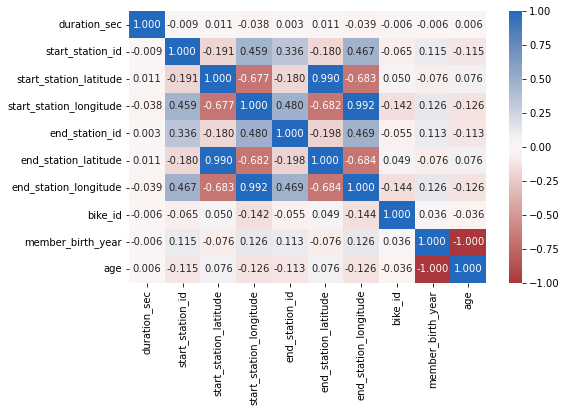

```python
# lets plot a correlation plot of our numeric columns to see how the fare amongst each other
plt.figure(figsize = [8, 5])
sb.heatmap(df[numeric_vars].corr(), annot = True, fmt = '.3f',
           cmap = 'vlag_r', center = 0)
plt.show()
```

```
(183412, 19)
(400, 19)
```

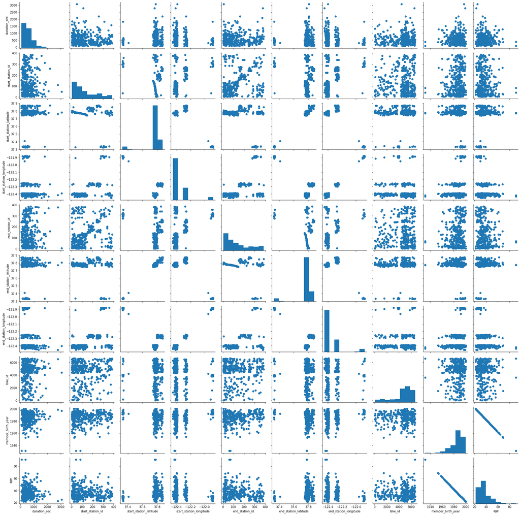

```python
# plot matrix: we plot 400 sample of all rides so that plots are clearer and they render faster
print(df.shape)
df_samp = df.sample(n=400, replace = False)
print(df_samp.shape)

g = sb.PairGrid(data = df_samp, vars = numeric_vars)
g = g.map_diag(plt.hist, bins = 8);
g.map_offdiag(plt.scatter)
plt.show()
```

> From the graphs shown, it is evident that the correlation relationship between some features to another is below 50% (positive correlation) while some are more than 50% (negetively correlated) and less than a few are more than 50% (postively correlated)

> Lets pick some of these correlated features and plot a scatter plot of just the two features for more graphical view

```python
def scatterplot(data, xvariable, yvariable):
    '''
    This function is to be used to
    create a scatterplot that shows
    correlation between two features in
    our dataset using 400 samples for clear
    and concise visuals
    '''
    #plt.figure is used to set the dimension of our plots
    plt.figure(figsize=[15,6])
    #lets plot the regplot using seaborn
    sb.regplot(data=df.sample(400), x=xvariable, y=yvariable);
    #plt.title gives the graph a title
    plt.title(f'correlation between {xvariable} and {yvariable}'.title(), fontsize=14, weight = "bold")
    #plt.xlable gives the graph a label on the x axis
    plt.xlabel(xvariable.title(), fontsize=10, weight="bold")
    #plt.yvariable gives the graph a label on the y axis
    plt.ylabel(yvariable.title(),fontsize=10, weight="bold")
```

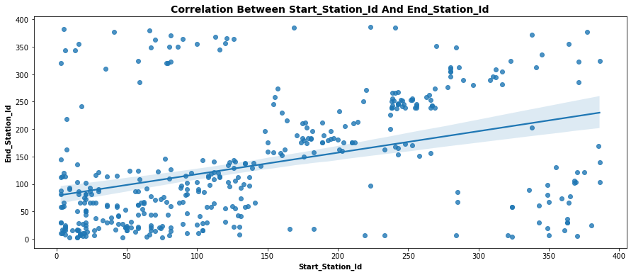

```python
# lets see a visual of the correlation between start & end stations id
scatterplot(df, 'start_station_id', 'end_station_id')
```

> from the above graph, you can see that start_station_id has a positive correlation with end_station_id

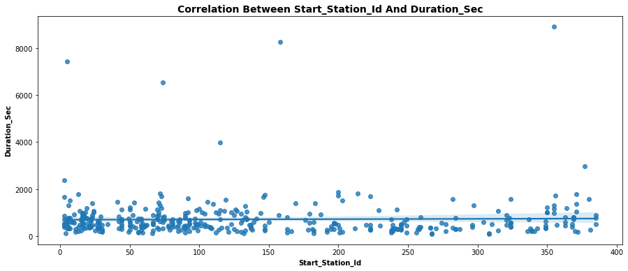

```python
# lets see if there is any correlation between start_station_id and duration_sec
scatterplot(df, 'start_station_id', 'duration_sec')
```

> The above graph shows no correlation between both features

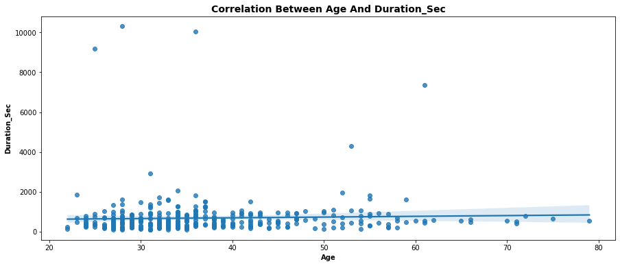

```python
# lets see if there is any correlation between age and duration_sec
scatterplot(df, 'age' , 'duration_sec')
```

> Age and duration_sec has no correlation

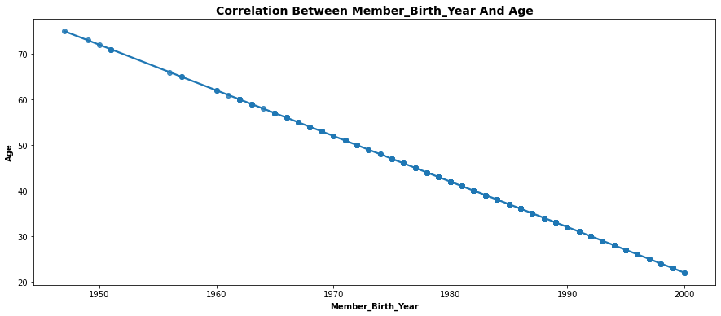

```python
# lets see if there is any correlation between member_birth_year and age
scatterplot(df, 'member_birth_year', 'age')
```

> The above shows that there is a high negetive correlation between members birth year and their age. It means as age increases, the year of birth decreases.

> Up next, we plot a boxplot to see the distribution of few numeric columns with some categorical columns

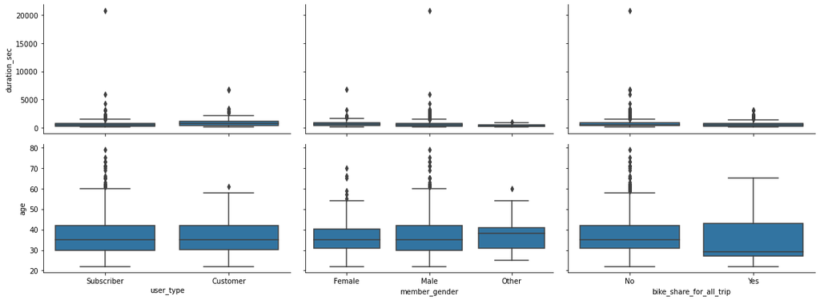

```python
# using a sample size of 1000, lets create a boxplot of earlier grouped categorical columns against duration_sec and age
df_samp = df.sample(n=1000, replace = False)


def boxgrid(x, y, **kwargs):
    """ function for creating box plots with seaborn's PairGrid
    on a sample of 1000. """
    default_color = sb.color_palette()[0]
    sb.boxplot(x=x, y=y, color=default_color)

plt.figure(figsize = [10, 10])
g = sb.PairGrid(data = df_samp, y_vars = ['duration_sec', 'age'], x_vars = categoric_vars,
                height = 3, aspect = 1.8)
g.map(boxgrid)
plt.show()
```

```python
# plot function to plot not visible boxplots
base_color = sb.color_palette()[0]
def boxgraph(data, xvariable, yvariable, color):
    '''function to create a boxplot of duration_sec against other
    features for better understanding'''
    plt.figure(figsize = [10, 5])
    sb.boxplot(data = data, x = xvariable, y = yvariable, color = color)
    plt.ylim([-10, 5000])
    plt.xlabel(xvariable.title())
    plt.ylabel(yvariable.title())
    plt.title(f'Box plot of {xvariable} and {yvariable}'.title())
    plt.show()
```

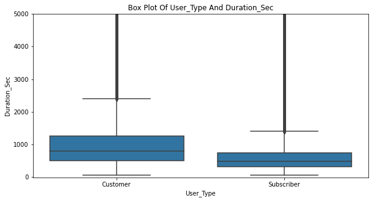

```python
# boxplot of user_type against duration duration
boxgraph(df, 'user_type', 'duration_sec', base_color)
```

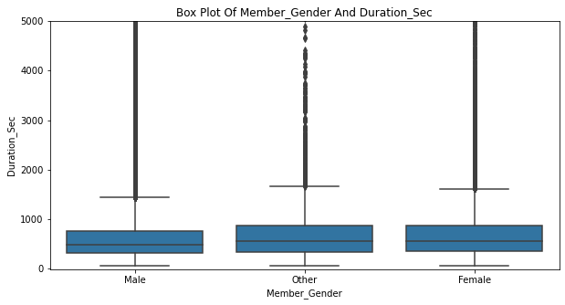

```python
# boxplot of member_gender against duration duration
boxgraph(df, 'member_gender', 'duration_sec', base_color)
```

> The previous (first boxplot) output shows that customers user_type had more trip (duration_sec) than the subscriber user_types when we plot a few samples. The male gender is seen to have less trip (duration_sec) than the female and other gender type in the above boxplot.

> Less number of persons within the age features are identified as female with the highest gender identified being others. More persons within age features prefer to subscribe as a user than being a customer.

> We will further plot the categorical features against each other to see how well they are related (relationship).

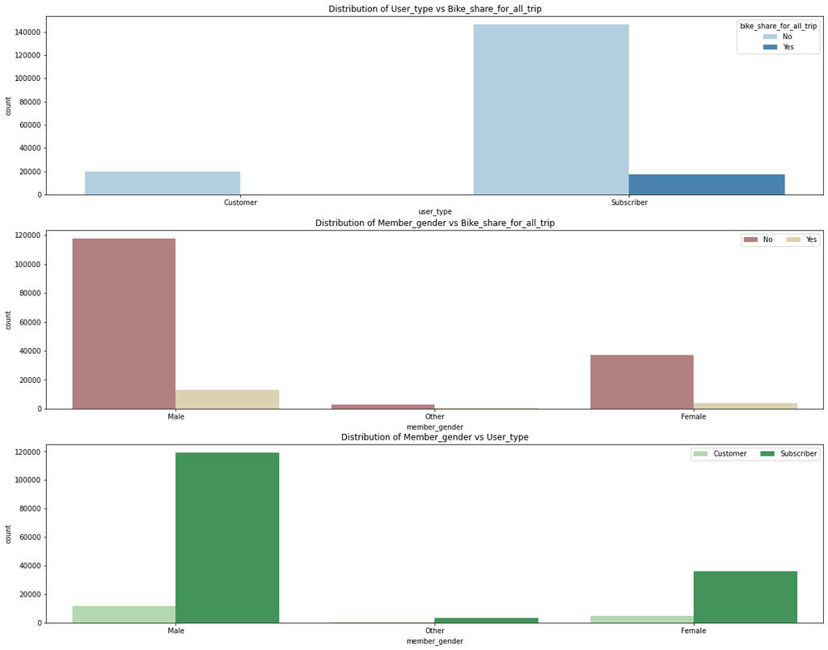

```python
# create 3 subplots using the full data.
plt.figure(figsize = [20, 16])

# subplot 1: user_type vs bike_share_for_all_trip
plt.subplot(3, 1, 1)
sb.countplot(data = df, x = 'user_type', hue = 'bike_share_for_all_trip', palette = 'Blues')
plt.title('Distribution of User_type vs Bike_share_for_all_trip')

# subplot 2: member_gender vs. bike_share_for_all_trip
ax = plt.subplot(3, 1, 2)
sb.countplot(data = df, x = 'member_gender', hue = 'bike_share_for_all_trip', palette = 'pink')
ax.legend(ncol = 2) # re-arrange legend to reduce overlapping
plt.title('Distribution of Member_gender vs Bike_share_for_all_trip')

# subplot 3: member_gender vs. user_type, use different color palette
ax = plt.subplot(3, 1, 3)
sb.countplot(data = df, x = 'member_gender', hue = 'user_type', palette = 'Greens')
ax.legend(loc = 1, ncol = 2) # re-arrange legend to remove overlapping
plt.title('Distribution of Member_gender vs User_type')

plt.show()
```

> The above out was plotted using all samples of the data and thus may be difficult to read. So, lets plot with 1000 samples and see.

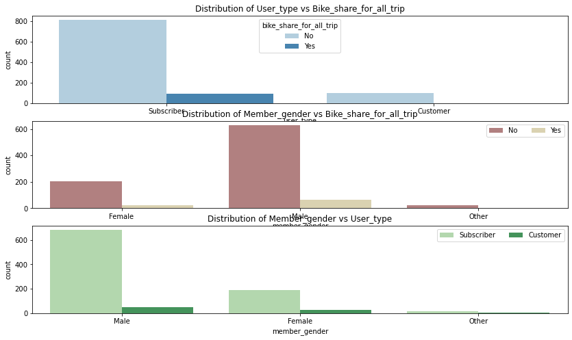

```python
# lets plot each subplot with 1000 samples.
plt.figure(figsize = [14, 8])

# subplot 1: user_type vs bike_share_for_all_trip
plt.subplot(3, 1, 1)
sb.countplot(data = df.sample(1000), x = 'user_type', hue = 'bike_share_for_all_trip', palette = 'Blues')
plt.title('Distribution of User_type vs Bike_share_for_all_trip')

# subplot 2: member_gender vs. bike_share_for_all_trip
ax = plt.subplot(3, 1, 2)
sb.countplot(data = df.sample(1000), x = 'member_gender', hue = 'bike_share_for_all_trip', palette = 'pink')
ax.legend(ncol = 2) # re-arrange legend to reduce overlapping
plt.title('Distribution of Member_gender vs Bike_share_for_all_trip')

# subplot 3: member_gender vs. user_type, use different color palette
ax = plt.subplot(3, 1, 3)
sb.countplot(data = df.sample(1000), x = 'member_gender', hue = 'user_type', palette = 'Greens')
ax.legend(loc = 1, ncol = 2) # re-arrange legend to remove overlapping
plt.title('Distribution of Member_gender vs User_type')

plt.show()
```

> The above confirms the analysis of our boxplot and shows very little relationship among the categorical features.

### Did you observe any interesting relationships between the other features (not the main feature(s) of interest)?

> The relationship between start_station_latitude and end_station_latitude was about 99% (positive correlation) which came as a surprise as I was expecting less percentage correlation since the stations of starting and ending a trip was entirely different locations. Same degree of percentage was equally observed between start_station_longitude and end_station_longitude. The correlation between start_station_latitude and end_station_longitude was more than 50% negetively correlated (-0.68) and same degree of correlation was seen between end_station_latitude and start_station_longtitude, it seems both the start_station and end_station are both in the same geographical location.

## Multivariate Exploration

> Since we are more particular about trends that will cause a member to share bike, we will limit our plots to those who actually shared bike.

```python
# # lets convert the values in our target column from object to intger (! means a bike was shared and 0 means bike was not shared)
# df['bike_share_for_all_trip'] = df['bike_share_for_all_trip'].map({'Yes': 1, 'No': 0})
```

```python
# lets create a sub dataset from our dataset (seperate those who shared from those who did not)
shared_bike = df[df['bike_share_for_all_trip'] == 'Yes']
shared_not = df[df['bike_share_for_all_trip'] == 'No']
```

```python
#lets also create a numeric column of our target variable, so that we can plot easily
df['numeric_all_trip'] = (df['bike_share_for_all_trip'] == 'Yes').astype(int)
```

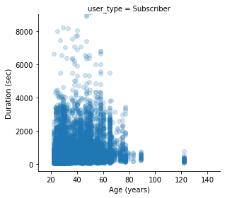

```python
# lets see the distribution of users that actually shared their bike using only the sub dataset for those who shared bike
user_type = sb.FacetGrid(data = shared_bike, col = 'user_type', col_wrap = 3, height = 4,
                    xlim = [10, 150], ylim = [-400, 9000])
user_type.map(plt.scatter, 'age', 'duration_sec', alpha = 0.2)
user_type.set_xlabels('Age (years)')
user_type.set_ylabels('Duration (sec)')
plt.show()
```

> Users that subscribe are the only ones to actually share a bike and most sharing occured below 60 years of age while members below 30 covered the most duration_sec in total and members around 50 having a high duration per trip. The oldest age that shared bike in the user category was around 125 there about.

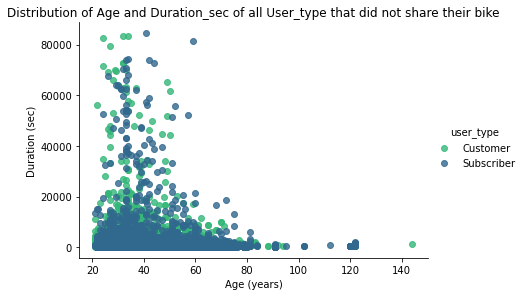

```python
# lets see the distribution of duration and age on user_types that did not share a bike
user_type = sb.FacetGrid(data = shared_not, hue = 'user_type', height = 4,
                    aspect = 1.5, palette = 'viridis_r')
user_type.map(sb.regplot, 'age', 'duration_sec', x_jitter = 0.02, fit_reg = False)
user_type.add_legend()
user_type.set_xlabels('Age (years)')
user_type.set_ylabels('Duration (sec)')
plt.title('Distribution of Age and Duration_sec of all User_type that did not share their bike')
plt.show()
```

> It seems subcribed members also has the higher percentage of not sharing bike with most duration higher than that of customers type based on the above distribution. The customer type though has the oldest rider among all riders (age can be seen to be above 140)

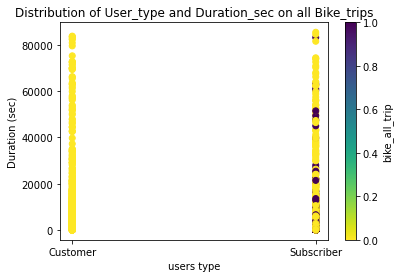

```python
# lets see the distribution of users on all dataset using the numeric value of all trips as a marker
plt.scatter(data = df, x = 'user_type', y= 'duration_sec', c = 'numeric_all_trip', cmap = 'viridis_r')
plt.colorbar(label = 'bike_all_trip')
plt.xlabel('users type')
plt.ylabel('Duration (sec)')
plt.title('Distribution of User_type and Duration_sec on all Bike_trips')
plt.show()
```

> The above scatter plot with hue of all bike rides on the side, clearly show that all customer types are coloured yellow (0 == 'No') did not share a bike during their ride whereas if you look at the subscriber line, you can see that it's coloured both yellow and dark blue (where yellow means 0 and 'No' while dark blue means 1 and 'Yes") but though, in small quantity as aginst the 0 ('No') which means fewer riders in subcribers category actually shared a bike.

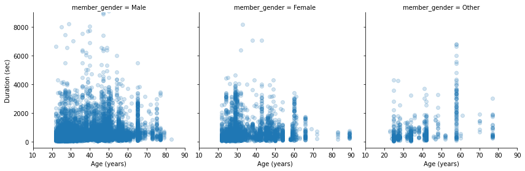

```python
# lets see the distribution of members_gender on those that actually shared a bike
rider_gender = sb.FacetGrid(data = shared_bike, col = 'member_gender', col_wrap = 3, height = 4,
                    xlim = [10, 90], ylim = [-400, 9000])
rider_gender.map(plt.scatter, 'age', 'duration_sec', alpha = 0.2)
rider_gender.set_xlabels('Age (years)')
rider_gender.set_ylabels('Duration (sec)')
plt.show()
```

> Earlier, we had seen female and other gender type having higher count in duration but then, in terms of those that actually shared a bike, male gender has the highest distribution and also, shows higher duration on trips.

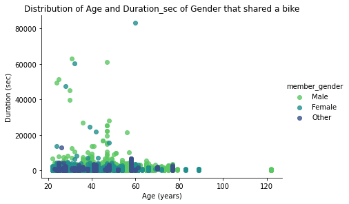

```python
# lets see the distribution of start_day on those that did share a bike
rider_start_day = sb.FacetGrid(data = shared_bike, hue = 'member_gender', height = 4,
                    aspect = 1.5, palette = 'viridis_r')
rider_start_day.map(sb.regplot, 'age', 'duration_sec', x_jitter = 0.0002, fit_reg = False)
rider_start_day.add_legend()
rider_start_day.set_xlabels('Age (years)')
rider_start_day.set_ylabels('Duration (sec)')
plt.title('Distribution of Age and Duration_sec of Gender that shared a bike')
plt.show()
```

> As against what we saw during the bivarate visual analysis, it is clear that the male gender covered more durations on all trips.

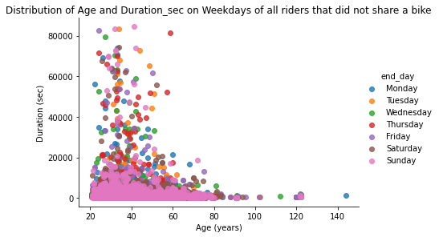

```python
plt.figure(figsize = ([20,8]))
rider_start_day = sb.FacetGrid(data = shared_not, hue = 'end_day', height = 4,
                    aspect = 1.5, hue_order = ['Monday', 'Tuesday', 'Wednesday', 'Thursday', 'Friday',
                                                                'Saturday', 'Sunday'])
rider_start_day.map(sb.regplot, 'age', 'duration_sec', x_jitter = 0.3, fit_reg = False)
rider_start_day.add_legend()
rider_start_day.set_xlabels('Age (years)')
rider_start_day.set_ylabels('Duration (sec)')
plt.title('Distribution of Age and Duration_sec on Weekdays of all riders that did not share a bike')
plt.show()
```

> A key point to note here is that the oldest rider on riders that did not share a bike rode on *Monday*

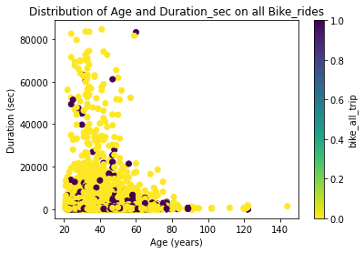

```python
# lets see the distribution of duration and age against a hue of all trips (either share or not)

plt.scatter(data = df, x = 'age', y= 'duration_sec', c = 'numeric_all_trip', cmap = 'viridis_r')
plt.colorbar(label = 'bike_all_trip')
plt.xlabel('Age (years)')
plt.ylabel('Duration (sec)')
plt.title('Distribution of Age and Duration_sec on all Bike_rides')
plt.show()
```

### Talk about some of the relationships you observed in this part of the investigation. Were there features that strengthened each other in terms of looking at your feature(s) of interest?

> Male gender showed higher percentage on both fronts (sharing and not sharing a bike). Though, there was a surge on *Other gender type* at age 60 among those who shared a bike. Users that subscribed, and are mostly men aged between 25 - 30 showed higher percentage in sharing a bike. I had expected the female gender or other to top the list.

### Were there any interesting or surprising interactions between features?

> Seeing the male gender top the list of those that actually shared a bike was a surprise to me. I had guessed that subscriber user_type may have an effect on why a user might want to share a bike, that hypothesis proved to be true. I was not expecting same day to top the start day and end day. Seeing a rider more than 140 years not sharing a bike is surprising too.

## Conclusions

> In general, male gender topped the list of those who shared and also did not share a bike during the trip. A good percent of persons around 60 years of age on the other gender also covered more duration in seconds.

> Both the start station latitude and end station latitude has positive effect on our dataset, I guess this showed how smooth trip was. Same can also be said about their respective longitudes.

> Younger people covered more distances when grouped but then, I was not expecting same group to top the chart when it came to bike sharing. I had expected persons of older age.

> No user_type as a customer shared a bike. Why this is so baffles me but then, a small percentage of subscribed user_type shared a bike. The percentage of subscribe users that did not share a bike was higher than those of same user_type who did share a bike.

> A summary of my analysis showed that longer duration does not guarantee that a rider will share a bike. Been older as a rider doesn't mean a rider will share a bike as it was evident that younger riders were the ones who shared a bike.

```python
df.shape
```

```
(183412, 20)
```